Ministerio de Salud - Tierra del Fuego A e IAS - Unidad Centinela Hepatitis Virales

# Unidad Centinela de Hepatitis Virales

# Tierra del Fuego A e IAS (2018 - 2025)

## **1.Introducción**

Las hepatitis virales constituyen un problema de salud pública a nivel mundial, con impacto variable según región, acceso al sistema sanitario, cobertura de vacunación y disponibilidad de diagnóstico oportuno y tratamiento antiviral.

La estrategia global impulsada por la Organización Mundial de la Salud propone como meta para el año 2030 la eliminación de las hepatitis virales como amenaza para la salud pública, estableciendo objetivos concretos de reducción del 90% en nuevas infecciones y 65% en mortalidad asociada.

En Argentina, las hepatitis A, B y C representan las principales etiologías virales, con diferentes patrones de transmisión, evolución clínica y carga de enfermedad. La hepatitis B y C son responsables de la mayor proporción de cirrosis, insuficiencia hepática y carcinoma hepatocelular, generando un impacto sanitario, social y económico significativo.

En la Provincia de Tierra del Fuego, Antártida e Islas del Atlántico Sur, las características geográficas —territorio insular, dispersión poblacional y distancia de centros de alta complejidad— configuran un escenario epidemiológico particular que requiere estrategias locales de vigilancia, diagnóstico y tratamiento, para poder aplicar Politicas publicas acorde a las características de nuestra pobleacion.

## **2.Objetivos**

### **Objetivo general**

El presente boletín tiene como objetivo describir y analizar la situación epidemiológica en el periodo 2018-2025 de las hepatitis virales en la provincia, para aportar información para la toma de decisiones sanitarias.

### **Objetivos específicos**

Determinar incidencia y prevalencia por tipo de hepatitis.

Analizar distribución por edad, sexo y ciudad.

Identificar dificultades y falencias en el circuito de abordaje

Describir proporción de enfermedad avanzada.

Analizar tendencia temporal

Proponer líneas de acción sanitaria

## **3.Metodología**

### 3.1 Diseño

Estudio descriptivo, observacional y retrospectivo

### 3.2 Fuentes de información

Sistema Nacional de Vigilancia (SNVS 2.0).

Laboratorios provinciales.

Registros hospitalarios a partir de Historia Clinica digital (Ushuaia, Río Grande, Tolhuin).

Programa Nacional de Hepatitis Virales

Registro propio del servicio de Hepatología

Unidad Centinela de Hepatitis Virales

Bancos de sangre

### 3.3 Definición de caso

Se utilizaron las definiciones vigentes nacionales para hepatitis A, B, C

### 3.4 Variables analizadas

1. Categorización de las Hepatitis: se utilizaron las clasificaciones manuales del SNVS 2.0 y se construyeron variables derivadas del análisis de las fuentes de datos disponibles para su clasificación.

   Hepatitis B
   - Aguda: hepatitis aguda definida por laboratorio y clínica sin contar documentada la evolución a crónica o resolución
   - Aguda y resuelta: aguda definida por laboratorio y clinica documentando la resolución de la misma por la presencia de Anti s
   - Resuelta: paciente asintomático con core + con antis +
   - Crónica: persistencia de Hbsag por más de 6 meses
   - Sin datos: no se puede categorizar con los datos documentados provenientes de las fuentes de información consultadas.

   Hepatitis C
   - Crónica: persistencia de infección con CV positiva mayor a 6 meses
   - Sin datos: no se puede categorizar con los datos documentados provenientes de las fuentes de información consultadas.
2. Grupo de edad
3. Sexo legal
4. Ciudad de residencia
5. Cirrosis: determinada por evidencia clínicas, determinado por imágenes biopsia o elastografía.
6. Transplante
7. Hepatocarcinoma
8. Defunción
9. Tratamiento: Indicación y acceso documentado en HC.
10. Resultado al tratamiento: si logra Respuesta Viral Sostenida en caso de Hepatitis C, o CV indetectable en Hepatitis B.
11. Pérdida de seguimiento: definido en pacientes crónicos como la falta de control a los 6 meses de la ultima consulta.

### 3.5 Análisis estadístico

Para las variables enunciadas se calcularon frecuencias absolutas, porcentajes y tasas de prevalencia por 100.000 habitantes en base a las proyecciones de población para la provincia de Tierra del Fuego publicadas por el INDEC a partir de los censos 2010 y 2022.

## **4.Situación Epidemiológica por Tipo de HV**

En el período comprendido entre los años 2018 a 2025 en la provincia de Tierra del Fuego A e IAS, se notificaron 199 casos de Hepatitis Virales.

### **Casos confirmados y tasas por año**

**Tabla 1.** Distribución de casos confirmados y tasas de prevalencia de Hepatitis Virales. Unidad Centinela de HV, Tierra del Fuego. SE 1/2018–SE 52/2025.

Casos y tasas de HV en Tierra del Fuego

Período 2018–2025

| Año | HVB | Tasa HVB | HVC | Tasa HVC | Total HV/Año |
| --- | --- | --- | --- | --- | --- |
| 2018 | 4 | 2.6 | 10 | 6.6 | 14 |
| 2019 | 10 | 6.4 | 8 | 5.1 | 18 |
| 2020 | 4 | 2.5 | 4 | 2.5 | 8 |
| 2021 | 4 | 2.5 | 1 | 0.6 | 5 |
| 2022 | 6 | 3.1 | 13 | 6.8 | 19 |
| 2023 | 7 | 3.6 | 15 | 7.7 | 22 |
| 2024 | 5 | 2.5 | 12 | 6.1 | 17 |
| 2025 | 7 | 3.5 | 9 | 4.5 | 16 |

Fuente: Elaboración propia con datos de SNVS 2.0

**Gráfico 1.** Casos confirmados y tasas de Hepatitis Virales por año. Unidad Centinela de HV, Tierra del Fuego. SE 1/2018–SE 52/2025.

[interactive chart not shown]

Fuente: Elaboración propia con datos de SNVS 2.0

### **Proporciones de casos confirmados según tipo de HV por año**

Proporciones de casos confirmados según tipo de hepatitis por año, tomando como referencia la fecha de recolección en papel registrada en el SNVS, correspondiente a la fecha mínima registrada entre la fecha de consulta clínica y la fecha de toma de muestra de laboratorio.

**Gráfico 2.** Proporción de casos confirmados de Hepatitis Virales por año. Unidad Centinela de HV, Tierra del Fuego. SE 1/2018–SE 52/2025.

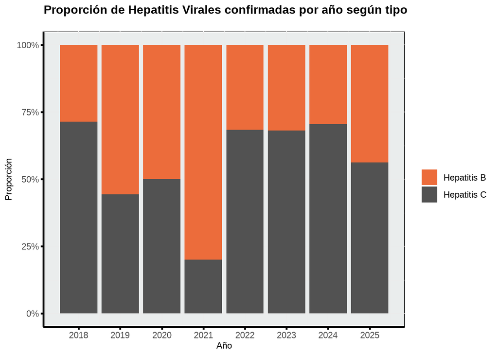

Fuente: Elaboración propia con datos de SNVS 2.0

### **Hepatitis B**

Los casos de Hepatitis B notificados y categorizados corresponden a un total de 66 casos.

**Tabla 2.** Categorización de Hepatitis B. Unidad Centinela de HV, Tierra del Fuego. SE 1/2018–SE 52/2025.

Clasificación de casos de HVB

Período 2018–2025

| Clasificación de HBV | Número de casos | Porcentaje sobre el total de HVB |
| --- | --- | --- |
| Aguda | 8 | 12.1 |
| Crónica | 35 | 53.0 |
| Descartado | 3 | 4.5 |
| Resuelta | 6 | 9.1 |
| Sin datos | 14 | 21.2 |
| Total | 66 | 99.9 |

Fuente: Elaboración propia con datos de Unidad Centinela HV.

Los casos de Hepatitis B confirmados (agudas, crónicas y resueltas) corresponden a un total de 49 casos.

**Tabla 3.** Frecuencia absoluta y relativa de co-infección VIH y VHC en pacientes con Hepatitis B. Unidad Centinela de HV, Tierra del Fuego. SE 1/2018–SE 52/2025.

Co-infección en HVB

Período 2018–2025

| Co-infección | Número de casos | Porcentaje |
| --- | --- | --- |
| NO | 30 | 61.2 |
| Sin datos | 14 | 28.6 |
| HIV | 3 | 6.1 |
| HIV/HCV | 1 | 2.0 |
| NA | 1 | 2.0 |
| Total | 49 | 99.9 |

Fuente: Elaboración propia con datos de Unidad Centinela HV.

### **Hepatitis B Aguda**

**Tabla 4.** Distribución de grupo etario de Hepatitis B Aguda. Unidad Centinela de HV, Tierra del Fuego. SE 1/2018–SE 52/2025.

Grupos etarios HVB aguda

Período 2018–2025

| Grupo etario | Casos | Porcentaje |
| --- | --- | --- |
| De 25 a 34 años | 2 | 25.0 |
| De 35 a 44 años | 3 | 37.5 |
| De 45 a 65 años | 2 | 25.0 |
| Mayores de 65 años | 1 | 12.5 |
| Total | 8 | 100.0 |

Fuente: Elaboración propia con datos de Unidad Centinela HV.

**Tabla 6.** Distribución por sexo de Hepatitis B Aguda. Unidad Centinela de HV, Tierra del Fuego. SE 1/2018–SE 52/2025.

Casos de HVB Aguda según sexo

| Sexo | Casos | Porcentaje |
| --- | --- | --- |
| M | 8 | 100 |
| Total | 8 | 100 |

Fuente: Elaboración propia con datos de Unidad Centinela HV.

### **Hepatitis B Crónica**

**Tabla 5.** Distribución de grupo etario de Hepatitis B Crónica. Unidad Centinela de HV, Tierra del Fuego. SE 1/2018–SE 52/2025.

Grupos etarios HVB crónica

Período 2018–2025

| Grupo etario | Casos | Porcentaje |
| --- | --- | --- |
| De 20 a 24 años | 1 | 2.9 |
| De 25 a 34 años | 2 | 5.7 |
| De 35 a 44 años | 10 | 28.6 |
| De 45 a 65 años | 17 | 48.6 |
| Mayores de 65 años | 5 | 14.3 |
| Total | 35 | 100.1 |

Fuente: Elaboración propia con datos de Unidad Centinela HV.

**Tabla 5.** Distribución por sexo de Hepatitis B Crónica. Unidad Centinela de HV, Tierra del Fuego. SE 1/2018–SE 52/2025.

Casos de HVB crónica según sexo

| Sexo | Casos | Porcentaje |
| --- | --- | --- |
| F | 15 | 42.9 |
| M | 20 | 57.1 |
| Total | 35 | 100.0 |

Fuente: Elaboración propia con datos de Unidad Centinela HV.

**Tabla 6.** Casos y porcentajes de pacientes con cirrosis en Hepatitis B Crónica. Unidad Centinela de HV, Tierra del Fuego. SE 1/2018–SE 52/2025.

Cirrosis en HVB

| Cirrosis | Casos | Porcentaje |
| --- | --- | --- |
| NO | 20 | 57.1 |
| Sin datos | 14 | 40.0 |
| SI | 1 | 2.9 |
| Total | 35 | 100.0 |

Fuente: Elaboración propia con datos de Unidad Centinela HV.

**Tabla 7.** Casos y porcentajes de pacientes con HCC en Hepatitis B Crónica. Unidad Centinela de HV, Tierra del Fuego. SE 1/2018–SE 52/2025.

Hepatocarcinoma en HVB

| HCC | Casos | Porcentaje |
| --- | --- | --- |
| NO | 23 | 65.7 |
| Sin datos | 12 | 34.3 |
| Total | 35 | 100.0 |

Fuente: Elaboración propia con datos de Unidad Centinela HV.

**Tabla 8.** No se registraron transplantes en HVB crónica. Unidad Centinela de HV, Tierra del Fuego, Tierra del Fuego. SE 1/2018–SE 52/2025.

Transplante en HVB

| Transplante | Casos | Porcentaje |
| --- | --- | --- |
| NO | 23 | 65.7 |
| Sin datos | 12 | 34.3 |
| Total | 35 | 100.0 |

Fuente: Elaboración propia con datos de Unidad Centinela HV.

**Tabla 9.** Casos y porcentajes de pacientes fallecidos con Hepatitis B Crónica. Unidad Centinela de HV, Tierra del Fuego. SE 1/2018–SE 52/2025.

Fallecidos en HVB

| Fallecido | Casos | Porcentaje |
| --- | --- | --- |
| NO | 34 | 97.1 |
| SI | 1 | 2.9 |
| Total | 35 | 100.0 |

Fuente: Elaboración propia con datos de Unidad Centinela HV.

**Tabla 10.** Casos y porcentajes de pacientes que recibieron tratamiento con Hepatitis B Crónica. Unidad Centinela de HV, Tierra del Fuego. SE 1/2018–SE 52/2025.

Tratamiento en HVB

| Tratamiento | Casos | Porcentaje |
| --- | --- | --- |
| NO | 14 | 40.0 |
| Sin datos | 12 | 34.3 |
| SI | 9 | 25.7 |
| Total | 35 | 100.0 |

Fuente: Elaboración propia con datos de Unidad Centinela HV.

### **Hepatitis C**

**Tabla 11.** Casos y porcentajes de pacientes con Hepatitis C según categorización. Unidad Centinela de HV, Tierra del Fuego. SE 1/2018–SE 52/2025.

Clasificación de casos de HVC

Período 2018–2025

| Clasificación de HVC | Número de casos | Porcentaje sobre el total de notificados de HVC |
| --- | --- | --- |
| SI | 61 | 62.2 |
| DESCARTADO | 20 | 20.4 |
| SIN DATOS | 17 | 17.3 |
| Total | 98 | 99.9 |

Fuente: Elaboración propia con datos de Unidad Centinela HV.

**Tabla 4.** Distribución de grupo etario de Hepatitis C. Unidad Centinela de HV, Tierra del Fuego. SE 1/2018–SE 52/2025.

Grupos etarios HVC confirmada

Período 2018–2025

| Grupo etario | Casos | Porcentaje |
| --- | --- | --- |
| De 25 a 34 años | 1 | 1.6 |
| De 35 a 44 años | 10 | 16.4 |
| De 45 a 65 años | 42 | 68.9 |
| Mayores de 65 años | 8 | 13.1 |
| Total | 61 | 100.0 |

Fuente: Elaboración propia con datos de Unidad Centinela HV.

**Tabla 6.** Distribución por sexo de Hepatitis C. Unidad Centinela de HV, Tierra del Fuego. SE 1/2018–SE 52/2025.

Casos de HVC según sexo

| Sexo | Casos | Porcentaje |
| --- | --- | --- |
| F | 29 | 47.5 |
| M | 32 | 52.5 |
| Total | 61 | 100.0 |

Fuente: Elaboración propia con datos de Unidad Centinela HV.

**Tabla 12.** Casos y porcentajes de pacientes confirmados de Hepatitis C según co - infección HVB y VIH. Unidad Centinela de HV, Tierra del Fuego. SE 1/2018–SE 52/2025.

Co-infección en casos confirmados de HVC

Período 2018–2025

| Co-infección | Número de casos | Porcentaje sobre el total de confirmados de HVC |
| --- | --- | --- |
| NO | 51 | 83.6 |
| HIV | 8 | 13.1 |
| VHB | 1 | 1.6 |
| NA | 1 | 1.6 |
| Total | 61 | 99.9 |

Fuente: Elaboración propia con datos de Unidad Centinela HV.

**Tabla 13.** Casos y porcentajes de pacientes confirmados de Hepatitis C según cirrosis. Unidad Centinela de HV, Tierra del Fuego. SE 1/2018–SE 52/2025.

Pacientes con cirrosis en HVC

Período 2018–2025

| Cirrosis | Número de casos | Porcentaje sobre el total de crónicos con HVC |
| --- | --- | --- |
| NO | 37 | 60.7 |
| SI | 16 | 26.2 |
| SIN DATOS | 8 | 13.1 |
| Total | 61 | 100.0 |

Fuente: Elaboración propia con datos de Unidad Centinela HV.

**Tabla 14.** Casos y porcentajes de pacientes confirmados de Hepatitis C según hepatocarcinoma. Unidad Centinela de HV, Tierra del Fuego. SE 1/2018–SE 52/2025.

Pacientes con hepatocarcinoma en HVC

Período 2018–2025

| Hepatocarcinoma | Número de casos | Porcentaje sobre el total de confirmados HVC |
| --- | --- | --- |
| NO | 51 | 83.6 |
| SIN DATOS | 7 | 11.5 |
| SI | 3 | 4.9 |
| Total | 61 | 100.0 |

Fuente: Elaboración propia con datos de Unidad Centinela HV.

**Tabla 15.** Casos y porcentajes de pacientes confirmados de Hepatitis C según transplante. Unidad Centinela de HV, Tierra del Fuego. SE 1/2018–SE 52/2025.

Pacientes transplantados en HVC

Período 2018–2025

| Transplante | Número de casos | Porcentaje sobre el total de crónicos con HVC |
| --- | --- | --- |
| NO | 55 | 90.2 |
| SIN DATOS | 6 | 9.8 |
| Total | 61 | 100.0 |

Fuente: Elaboración propia con datos de Unidad Centinela HV.

**Tabla 16.** Casos y porcentajes de pacientes confirmados de Hepatitis C según defunción. Unidad Centinela de HV, Tierra del Fuego. SE 1/2018–SE 52/2025.

Pacientes fallecidos con HVC

Período 2018–2025

| Fallecido | Número de casos | Porcentaje |
| --- | --- | --- |
| NO | 49 | 80.3 |
| SI | 12 | 19.7 |
| Total | 61 | 100.0 |

Fuente: Elaboración propia con datos de Unidad Centinela HV.

**Tabla 17.** Casos y porcentajes de pacientes confirmados de Hepatitis C según tratamiento. Unidad Centinela de HV, Tierra del Fuego. SE 1/2018–SE 52/2025.

Pacientes que recibieron tratamiento con HVC

Período 2018–2025

| Tratamiento | Número de casos | Porcentaje |
| --- | --- | --- |
| SI | 41 | 67.2 |
| NO | 13 | 21.3 |
| SIN DATOS | 6 | 9.8 |
| Tto en curso | 1 | 1.6 |
| Total | 61 | 99.9 |

Fuente: Elaboración propia con datos de Unidad Centinela HV.

**Tabla 18.** Casos y porcentajes de pacientes confirmados de Hepatitis C según RVS. Unidad Centinela de HV, Tierra del Fuego. SE 1/2018–SE 52/2025.

Pacientes con RVS en HVC

Período 2018–2025

| Respuesta viral sostenida | Número de casos | Porcentaje |
| --- | --- | --- |
| SI | 34 | 82.9 |
| SIN DATOS | 4 | 9.8 |
| Tto en curso | 3 | 7.3 |
| Total | 41 | 100.0 |

Fuente: Elaboración propia con datos de Unidad Centinela HV.

## **5.Pérdida de seguimiento**

### **5.3 Fallecidos HVC**

[output not shown]

## **6.Distribución geográfica**

**Tabla 21.** Casos notificados y porcentajes según localidad de residencia. Unidad Centinela de HV, Tierra del Fuego. SE 1/2018–SE 52/2025.

Notificados de HV por localidad

Período 2018–2025

| Localidad | Casos notificados | % Notificados por localidad |
| --- | --- | --- |
| USHUAIA | 93 | 46.7 |
| RIO GRANDE | 74 | 37.2 |
| TOLHUIN | 14 | 7.0 |
| *SIN DATO* (*SIN DATO*) | 7 | 3.5 |
| *sin dato* | 4 | 2.0 |
| ANTARTIDA ARGENTINA | 1 | 0.5 |
| CIUDAD DE BUENOS AIRES | 1 | 0.5 |
| LAGO PUELO | 1 | 0.5 |
| RIO GALLEGOS | 1 | 0.5 |
| RIO TERCERO | 1 | 0.5 |
| SALTA | 1 | 0.5 |
| TIGRE | 1 | 0.5 |
| Total | 199 | 99.9 |

Fuente: Elaboración propia con datos de SNVS 2.0